# Optimización del presupuesto en campañas de marketing con analítica predictiva y prescriptiva

**Francisco Espiga**

*Abril, 2021*

Más sobre ciencia de datos: [**cienciadedatos.net**](https://cienciadedatos.net)

## Introducción

En este artículo exploraremos cómo el uso de modelos predictivos y prescriptivos nos permiten mejorar la intención de compra de los clientes detectando los factores (*drivers*) más influyentes en su decisión y optimizando el reparto del presupuesto (*budget*) para actividades de mejora de percepción del cliente.

Tras el análisis descriptivo inicial, utilizaremos un modelo de regresión logística para la etapa predictiva y optimización lineal para la prescriptiva.

## Información de sesión

```python
# Librerías
# ==============================================================================
from sinfo import sinfo
import numpy as np
import pandas as pd
import matplotlib.pyplot as plt
import random
import shap
import random
import pyomo.environ as pyo

from sklearn.linear_model import LogisticRegression
from sklearn.metrics import confusion_matrix, classification_report
from sklearn.model_selection import train_test_split
random.seed(1211)

sinfo()
```

```
-----
matplotlib  3.2.2
numpy       1.19.5
pandas      1.0.5
pyomo       5.7.1
shap        0.37.0
sinfo       0.3.1
sklearn     0.22.1
-----
IPython             7.12.0
jupyter_client      6.1.5
jupyter_core        4.6.3
jupyterlab          1.2.6
notebook            6.0.3
-----
Python 3.7.6 (default, Jan  8 2020, 19:59:22) [GCC 7.3.0]
Linux-5.4.0-70-generic-x86_64-with-debian-buster-sid
8 logical CPU cores, x86_64
-----
Session information updated at 2021-03-29 14:22
```

## Contexto de negocio

Para maximizar el rendimiento de las campañas de *marketing*, es muy importante ser capaz de valorar qué características de nuestros productos son las que más valoran nuestros clientes. Disponer de esta información permite dirigir las futuras inversiones y esfuerzos.

Uno de los instrumentos para conectar con los clientes potenciales son las encuestas, cada vez más sencillas de llevar a cabo y con un alcance mayor en el nuevo paradigma digital que estamos viviendo.

A lo largo de este documento, veremos cómo utilizar las respuestas de los entrevistados para identificar qué factores determinan su intención de compra y cuantificar su importancia relativa. Una vez obtenida esa importancia, es importante optimizar la asignación del presupuesto a cada factor (palanca) de modo que, la mejora de la percepción del cliente, se traduzca en el mayor incremento posible de intención de compra global.

Para contextualizarlo, supondremos que trabajamos en el sector de la automoción y queremos averiguar de cara al lanzamiento de un nuevo vehículo qué características son las que influyen más en nuestros clientes.

## Caso de uso

Se ha planteado a distintas personas que han entrado en nuestra web una pequeña encuesta, pidiéndoles que cifren de 0 a 10 cuánto valoran en los productos de nuestra marca las siguientes características:

- Diseño y estética
- Consumo de combustible
- Fiabilidad de la mecánica
- Innovación
- Precio

Además, se les ha preguntado por su intención de compra en los próximos 6 meses con valores en el mismo rango.

Tras haber obtenido un número razonable de encuestas (~10000), tenemos un set de datos con el siguiente aspecto:

```python
pd.DataFrame.from_dict(
    dict(zip(['diseño', 'consumo', 'fiabilidad', 'innovación', 'precio', 'intención_compra'],
             [np.random.randint(0,10,5) for i in range(6)])
        )
)
```

|  | diseño | consumo | fiabilidad | innovación | precio | intención_compra |
| --- | --- | --- | --- | --- | --- | --- |
| 0 | 2 | 2 | 1 | 0 | 7 | 7 |
| 1 | 5 | 5 | 9 | 9 | 5 | 9 |
| 2 | 6 | 5 | 2 | 3 | 2 | 3 |
| 3 | 9 | 8 | 7 | 2 | 1 | 2 |
| 4 | 9 | 9 | 0 | 2 | 0 | 2 |

Escalaremos los distintos *drivers* entre 0 y 1 (dividiendo por 10) y consideraremos únicamente como compras potenciales aquellas con una probabilidad de intención superior al 95%.

Vamos a suponer que nuestros clientes le dan una importancia base de:

- 1 a la innovación y al diseño.
- 2 al consumo, a la interacción de precio y fiabilidad.
- 3 al precio, que además está relacionado cuadráticamente con la intención de compra.

Teniendo en cuenta esto, su utilidad vendrá dada por la expresión:

$$z=Innovacion+Diseño+2*Consumo+2*(Precio\times Fiabilidad) + 3*(Precio²)$$

```python
n_samples = 10000

# variables explicativas -------------------------------------------------------
diseño = np.random.randint(0,10,n_samples)/10
consumo = np.random.randint(0,10,n_samples)/10
fiabilidad = np.random.randint(0,10,n_samples)/10
innovacion = np.random.randint(0,10,n_samples)/10
precio = np.random.randint(0,10,n_samples)/10
X = np.array([diseño, consumo, fiabilidad, innovacion, precio]).transpose()
feature_labels = ['diseño', 'consumo', 'fiabilidad', 'innovacion', 'precio']

# respuesta --------------------------------------------------------------------
z = (innovacion + diseño + 2*consumo + 2*precio*fiabilidad +3*((precio)**2))
pi_x = np.exp(z)/(1+np.exp(z))
y = 1*(pi_x>0.95)
```

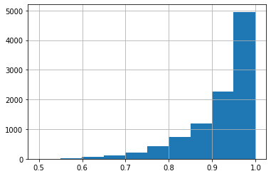

```python
pd.Series(pi_x).hist();
```

## Modelado

A continuación, exploraremos diferentes opciones de modelado y cómo extraer insights de ellas. En este caso, lo formularemos como un problema de clasificación y nuestra respuesta será binaria:

- 1: fuerte intención de compra.
- 0: sin intención de compra.

Para no llegar a conclusiones equivocadas y en caso de tratar con datos reales, sería importante verificar que la variable respuesta del el dataset esté balanceada. Podemos comprobar que es así y cada clase tiene aproximadamente un 50% de los datos. En caso contrario, podríamos utilizar diversas estrategias, como *subsampling* de la clase dominante o bien hacer *oversampling* de la minoritaria.

El *subsampling* es menos deseable, ya que perdemos información y no tenemos la garantía de que la muestra de datos que extraemos sea representativo del resto. Por otro lado, hacer *oversampling* de la clase minoritaria, recurriendo por ejemplo a *SMOTE* o utilizar *k-fold cross validation*, de modo que en cada subset de los datos de entrenamiento tomemos la clase minoritaria y un número de muestras equivalente de la dominante nos permite utilizar todos los datos de que disponemos.

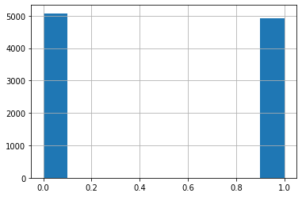

```python
pd.Series(y).hist()
```

```python
X_train, X_test, y_train, y_test = train_test_split(X, y, train_size = 0.8, stratify = y)
```

### Regresión logística

Aunque en este caso sabemos que la regresión logística no va a ser suficiente para modelar de manera totalmente precisa nuestro problema, debido a las relaciones cuadráticas con el precio y la interacción precio-fiabilidad, es interesante utilizarla como baseline frente a la que comparar el resto de modelos, al ser sencilla de implementar y explicable.

```python
clf = LogisticRegression(random_state=0).fit(X_train, y_train)
```

Evaluamos la calidad del modelo utilizando la matriz de confusión y observamos que tanto para *train* como para *test*, los resultados son homogéneos y de una calidad aceptable. En este caso, somos capaces de determinar con una precisión (*accuracy*) superior al 95% si un cliente va a comprar o no.

```python
confusion_matrix(y_train, clf.predict(X_train), normalize='true')
```

```
array([[0.96797241, 0.03202759],
       [0.03273281, 0.96726719]])
```

```python
print(classification_report(y_train, clf.predict(X_train)))
```

```
              precision    recall  f1-score   support

           0       0.97      0.97      0.97      4059
           1       0.97      0.97      0.97      3941

    accuracy                           0.97      8000
   macro avg       0.97      0.97      0.97      8000
weighted avg       0.97      0.97      0.97      8000
```

```python
CM_test = confusion_matrix(y_test, clf.predict(X_test), normalize='true')
```

```python
print(classification_report(y_test, clf.predict(X_test)))
```

```
              precision    recall  f1-score   support

           0       0.97      0.96      0.97      1015
           1       0.96      0.97      0.97       985

    accuracy                           0.97      2000
   macro avg       0.97      0.97      0.97      2000
weighted avg       0.97      0.97      0.97      2000
```

### Importancia de los drivers de compra

A continuación, vamos a utilizar los *shap values* para determinar, tanto la importancia relativa de las distintas variables exógenas (nuestros *drivers* de compra), como para cuantificar el impacto (utilidad marginal) que tiene cada *driver* sobre la percepción. Para esto último se recurre a [gráficos de dependencias parciales (PDP)](https://www.cienciadedatos.net/documentos/py16-interpretacion-modelos-graficos-pdp-ice.html).

```python
df_test = pd.DataFrame(X_test, columns = feature_labels)
```

```python
explainer = shap.LinearExplainer(clf, X_train, feature_perturbation="interventional")
shap_values = explainer.shap_values(df_test)
```

```
The feature_perturbation option is now deprecated in favor of using the appropriate masker (maskers.Independent, or maskers.Impute)
```

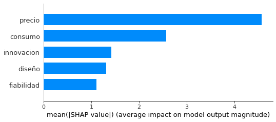

```python
shap.summary_plot(shap_values, df_test, plot_type='bar')
```

En este caso, vemos que el modelo es capaz de captar la importancia relativa de los distintos *drivers* de compra, aunque la interacción de fiabilidad y precio se ve enmascarada por la importancia de éste.

Esto es muy interesante pero insuficiente a la hora de determinar el impacto positivo de acciones de marketing específicas para cada *driver*, para ello y en el caso concreto de la regresión logística, tendremos que extraer los coeficientes del modelo para conectar cómo la variación de la percepción de cada *driver* afectaría a la intención de compra.

Usando los gráficos de dependencia parcial, podemos ganar una intuición de cómo cada *driver* afectaría a la intención antes de pasar a modelar el problema de optimización del presupuesto.

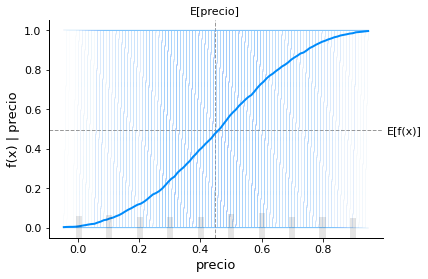

```python
shap.partial_dependence_plot("precio", clf.predict, df_test,
                             model_expected_value=True, feature_expected_value=True)
```

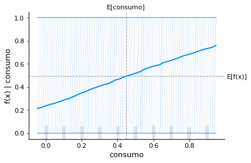

```python
shap.partial_dependence_plot("consumo", clf.predict, df_test,
                             model_expected_value=True, feature_expected_value=True)
```

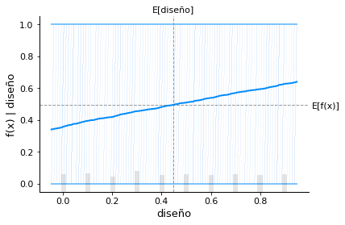

```python
shap.partial_dependence_plot("diseño", clf.predict, df_test,
                             model_expected_value=True, feature_expected_value=True)
```

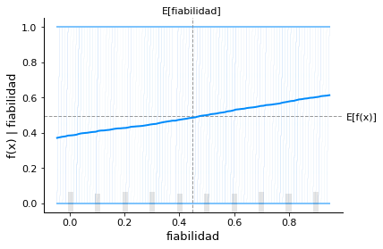

```python
shap.partial_dependence_plot("fiabilidad", clf.predict, df_test,
                             model_expected_value=True, feature_expected_value=True)
```

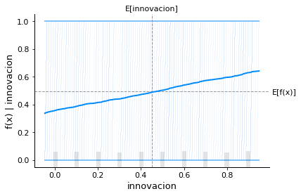

```python
shap.partial_dependence_plot("innovacion", clf.predict, df_test,
                             model_expected_value=True, feature_expected_value=True)
```

Observamos cómo los *drivers* principales son efectivamente el precio y el consumo.

Si bien una mejora en la percepción de cualquier *driver* conlleva un aumento de la intención de compra, la innovación, diseño y fiabilidad tienen una contribución marginal mucho menor que los otros dos, que serán en los que nos interesará centrarnos en primer término.

```python
dict(zip(feature_labels, np.log(clf.coef_).reshape(-1)))
```

```
{'diseño': 1.656303159853731,
 'consumo': 2.3224237883119336,
 'fiabilidad': 1.4763473464469679,
 'innovacion': 1.7322586304038865,
 'precio': 2.922333540338283}
```

Por último, podemos utilizar shap para analizar la decisión de compra de cada individuo de la muestra.

```python
shap.initjs()
```

```python
random_ok = np.random.choice(np.where(y_test == 1)[0].reshape(-1), 1)[0]
random_ko = np.random.choice(np.where(y_test == 0)[0].reshape(-1), 1)[0]
random_ok, random_ko
```

```
(460, 383)
```

```python
shap.force_plot(
    explainer.expected_value, shap_values[random_ok,:], X_test[random_ok,:],
    feature_names=feature_labels
)
```

```python
shap.force_plot(
    explainer.expected_value, shap_values[random_ko,:], X_test[random_ko,:],
    feature_names=feature_labels
)
```

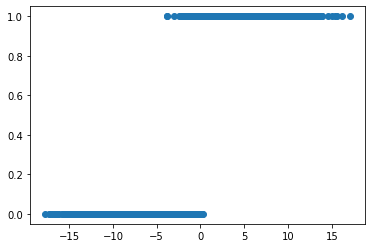

```python
plt.scatter(np.sum(shap_values, axis = 1), y_test);
```

### Optimización del presupuesto (*budget*)

Vamos a suponer ahora que queremos mejorar la percepción del cliente de cada uno de los *drivers* y para ello disponemos de un presupuesto de 1000 unidades monetarias (u.m.).

Cada mejora porcentual en la percepción de los *drivers* tendrá un coste asociado y un impacto en la intención de compra, que es lo que buscamos maximizar. Utilizaremos los datos de las encuestas y el modelo de regresión logística que hemos calculado previamente para construir el modelo de optimización.

Posteriormente, con los datos de validación, mediremos el impacto de nuestra asignación con la nueva intención de compra. Es importante tener en cuenta que, es gracias a tener una precisión adecuada en nuestro modelo predictivo (la regresión logística), es decir, el modelo capturar de manera bastante acertada la relación entre *drivers* e intención de compra, lo que nos permite pasar a la siguiente etapa, la prescriptiva. De no ser así, deberíamos buscar un modelo mejor ya que, si no, cualquier optimización posterior estaría basada en unas premisas que no son reflejo de la realidad del negocio.

Utilizamos los datos de las encuestas para saber el punto de partida y el margen de mejora:

```python
np.mean(X, axis = 0)
```

```
array([0.44847, 0.4505 , 0.4463 , 0.45117, 0.45125])
```

```python
X_train.shape
```

```
(8000, 5)
```

Todos los *drivers* tienen una percepción de en torno al 45%, consideraremos que el máximo margen de mejora por tanto sería del 50%, llevando la percepción de cada *driver* hasta un teórico máximo del 95%.

### Formalización del problema de optimización

A la hora de diseñar la función objetivo, tenemos que pensar que nuestra meta global es, mediante las acciones de marketing correspondientes, aumentar las ventas totales y ello se reflearía en el número de encuestados que habrían contestado afirmativamente a la intención de compra. Es decir :

$$ max\;z= \sum_{i\in sEncuestados}\pi(x)=\;\frac{1}{1+e^{-\beta_0 + \sum \beta_j x_j}} $$

Como hemos considerado que la intención de compra es una variable modelada como una distribución de Bernouilli y llamando $p$ a la probabilidad $P(Y=1)$, tenemos que:

$$ l=\frac{p}{1-p}=\beta_0 + \sum \beta_j x_j $$

Al ser las intenciones de compra de cada encuestado sucesos independientes, podemos entonces decir que será equivalente a maximizar la suma de todas las intenciones de compra.

$$ max\;z= \sum_{i\in\; sEncuestados}\sum_{j\in\; sDrivers} \beta_0 + \beta_j x_j $$

Y por último, modificamos la variable independiente para tener en cuenta el valor inicial de percepción de los encuestados y su incremento:

$$ max\;z= \sum_{i\in\; sEncuestados}\sum_{j\in\; sDrivers} \beta_j (pPercepcion_{i,j} + vIncrementoPercepcion_j) $$

Los coeficientes $\beta$ del modelo de regresión logística los llamaremos $pBeta$ en el de optimización.

**Sets**:

- $sDrivers$: cardinalidad 5 {precio, combustible, innovación, fiabilidad, diseño}
- $sEncuestados$: cardinalidad 8000, el número de encuestados de nuestro set

**Parámetros:**

- $pPrecioIncremento_{\:sDrivers}$: precio asociado al incremento porcentual de cada driver.
- $pPercepcion_{\:sEncuestados,\; sDrivers}$: percepción de cada driver por cada encuestado.
- $pBetas_{sDrivers}$: coeficiente de cada driver de compra.

**Variable de decisión:**

- $vIncrementoPercepcion_{\:sDrivers}$: variable de decisión con los puntos porcentuales de mejora que la acción de marketing va a proporcionar.

```python
# Definición del problema
model = pyo.ConcreteModel()

# sets
model.sDrivers = pyo.Set(initialize = feature_labels)
model.sEncuestados = pyo.Set(initialize = ["p_{}".format(i) for i in range(X_train.shape[0])])
```

```python
df_percepcion=pd.DataFrame(X_train, columns = feature_labels, index = ["p_{}".format(i) for i in range(X_train.shape[0])])
df_percepcion
```

|  | diseño | consumo | fiabilidad | innovacion | precio |
| --- | --- | --- | --- | --- | --- |
| p_0 | 0.1 | 0.3 | 0.3 | 0.9 | 0.8 |
| p_1 | 0.5 | 0.2 | 0.0 | 0.8 | 0.2 |
| p_2 | 0.3 | 0.3 | 0.6 | 0.7 | 0.6 |
| p_3 | 0.6 | 0.7 | 0.8 | 0.3 | 0.8 |
| p_4 | 0.1 | 0.8 | 0.5 | 0.9 | 0.5 |
| ... | ... | ... | ... | ... | ... |
| p_7995 | 0.0 | 0.3 | 0.2 | 0.7 | 0.9 |
| p_7996 | 0.7 | 0.6 | 0.1 | 0.2 | 0.9 |
| p_7997 | 0.4 | 0.9 | 0.4 | 0.8 | 0.9 |
| p_7998 | 0.2 | 0.4 | 0.9 | 0.0 | 0.2 |
| p_7999 | 0.8 | 0.2 | 0.1 | 0.8 | 0.4 |

8000 rows × 5 columns

```python
# parametros

model.pBetas = pyo.Param(model.sDrivers, initialize = dict(zip(feature_labels, clf.coef_.reshape(-1))))

def load_perception(model, encuesta, driver):
        return df_percepcion[driver][encuesta]

model.pPercepcion = pyo.Param(model.sEncuestados, model.sDrivers, initialize = load_perception)
```

```python
model.pBetas.display()
```

```
pBetas : Size=5, Index=sDrivers, Domain=Any, Default=None, Mutable=False
    Key        : Value
       consumo : 10.200367900456106
        diseño :  5.239903907249989
    fiabilidad :  4.376929041693824
    innovacion :  5.653408459329742
        precio :  18.58460482370923
```

```python
for i in model.pPercepcion.items():
    break
i, model.pPercepcion[('p_7998','innovacion')]
```

```
((('p_0', 'diseño'), 0.1), 0.0)
```

A continuación, vamos a integrar en el modelo los costes de las actividades de marketing. Recordemos que tenemos un presupuesto de 1000 u.m. y potencialmente podemos mejorar 50 puntos por *driver* hasta un total de 250 puntos.

El coste de mejora de 1 punto de percepción será para cada driver:

- Diseño: 10 u.m.
- Consumo: 21 u.m.
- Fiabilidad: 12 u.m.
- Innovación: 15 u.m.
- Precio: 36 u.m.

Recordemos que nuestros driver están escalados entre 0 y 1, por lo que un incremento unitario, escalado sería de 0.01.

```python
model.pPrecioIncremento = pyo.Param(
                            model.sDrivers,
                            initialize = dict(zip(feature_labels, [10,21,12,15,36]))
                          )
```

```python
model.pPrecioIncremento.display()
```

```
pPrecioIncremento : Size=5, Index=sDrivers, Domain=Any, Default=None, Mutable=False
    Key        : Value
       consumo :    21
        diseño :    10
    fiabilidad :    12
    innovacion :    15
        precio :    36
```

Es momento de integrar nuestra variable de decisión, que recordemos podrá ir desde 0 (no mejoramos ese *driver*) hasta una mejora máxima de 50 puntos. Además, supondremos que las mejoras serán en unidades completas, por lo que la variable de decisión será de tipo entero.

```python
model.vIncrementoPercepcion = pyo.Var(model.sDrivers, domain=pyo.NonNegativeIntegers, bounds=(0,50))
```

```python
model.vIncrementoPercepcion.display()
```

```
vIncrementoPercepcion : Size=5, Index=sDrivers
    Key        : Lower : Value : Upper : Fixed : Stale : Domain
       consumo :     0 :  None :    50 : False :  True : NonNegativeIntegers
        diseño :     0 :  None :    50 : False :  True : NonNegativeIntegers
    fiabilidad :     0 :  None :    50 : False :  True : NonNegativeIntegers
    innovacion :     0 :  None :    50 : False :  True : NonNegativeIntegers
        precio :     0 :  None :    50 : False :  True : NonNegativeIntegers
```

Del mismo modo, tenemos que integrar la restricción presupuestaria, es decir, que el coste total de las mejoras incrementales no supere nuestro *budget* de 1000 u.m.

```python
max_budget = 1000

model.ctBudget = pyo.Constraint(
                    expr= pyo.quicksum(model.vIncrementoPercepcion[i]*model.pPrecioIncremento[i] \
                                       for i in model.sDrivers)<=max_budget
                 )
```

Por último, implementamos la función objetivo descrita anteriormente.

```python
model.obj = pyo.Objective(
                sense = pyo.maximize,
                expr = pyo.quicksum(
                        (0.01*model.vIncrementoPercepcion[j]+model.pPercepcion[(i,j)])*model.pBetas[j] \
                        for i in model.sEncuestados for j in model.sDrivers
                        )
            )
```